[figure not shown]

# Unidad Centinela de Hepatitis Virales

# Tierra del Fuego A e IAS (2018 - 2025)

## **1.Introducción**

Las hepatitis virales constituyen un problema de salud pública a nivel mundial, con impacto variable según región, acceso al sistema sanitario, cobertura de vacunación y disponibilidad de diagnóstico oportuno y tratamiento antiviral.

La estrategia global impulsada por la Organización Mundial de la Salud propone como meta para el año 2030 la eliminación de las hepatitis virales como amenaza para la salud pública, estableciendo objetivos concretos de reducción del 90% en nuevas infecciones y 65% en mortalidad asociada.

En Argentina, las hepatitis A, B y C representan las principales etiologías virales, con diferentes patrones de transmisión, evolución clínica y carga de enfermedad. La hepatitis B y C son responsables de la mayor proporción de cirrosis, insuficiencia hepática y carcinoma hepatocelular, generando un impacto sanitario, social y económico significativo.

En la Provincia de Tierra del Fuego, Antártida e Islas del Atlántico Sur, las características geográficas —territorio insular, dispersión poblacional y distancia de centros de alta complejidad— configuran un escenario epidemiológico particular que requiere estrategias locales de vigilancia, diagnóstico y tratamiento, para poder aplicar Politicas publicas acorde a las características de nuestra pobleacion.

## **2.Objetivos**

### **Objetivos específicos**

Determinar incidencia y prevalencia por tipo de hepatitis.

Analizar distribución por edad, sexo y ciudad.

Identificar dificultades y falencias en el circuito de abordaje

Describir proporción de enfermedad avanzada.

Analizar tendencia temporal

Proponer líneas de acción sanitaria

## **3.Metodología**

### 3.1 Diseño

Estudio descriptivo, observacional y retrospectivo

### 3.2 Fuentes de información

Sistema Nacional de Vigilancia (SNVS 2.0).

Laboratorios provinciales.

Registros hospitalarios a partir de Historia Clinica digital (Ushuaia, Río Grande, Tolhuin).

Programa Nacional de Hepatitis Virales

Registro propio del servicio de Hepatología

Unidad Centinela de Hepatitis Virales

Bancos de sangre

### 3.3 Definición de caso

Se utilizaron las definiciones vigentes nacionales para hepatitis A, B, C

### 3.4 Variables analizadas

Edad.

Sexo.

Ciudad de residencia.

Establecimiento de Carga de la notificación

Tipo de hepatitis: A, B y C

### Categorización de la Hepatitis: aguda, crónica, resuelta

#### Para HBV

Aguda: hepatitis aguda definida por laboratorio y clínica sin contar documentada la evolución a crónica o resolución

Aguda y resuelta: aguda definida por laboratorio y clinica documentando la resolución de la misma por la presencia de Anti s

Resuelta: paciente asintomático con core + con antis +

Crónica: persistencia de Hbsag por más de 6 meses

Sin datos: no se puede categorizar con los datos documentados

#### Para HCV

Crónica: persistencia de infección con CV positiva mayor a 6 meses

Sin datos: no se puede categorizar con los datos documentados Presencia de cirrosis: determinada por evidencia clínicas, determinado por imágenes biopsia o elastografía

Evolución a trasplante, hepatocarcinoma o muerte documentada en HC

Indicación y acceso a tratamiento, documentado en HC

Resultado al tratamiento: si logra Respuesta Viral Sostenida en caso de Hepatitis C, o CV indetectable en Hepatitis B

Pérdida de seguimiento: definido en pacientes crónicos como la falta de control a los 6 meses de la ultima consulta

### 3.5 Análisis estadístico

Se calcularon tasas por 100.000 habitantes, proporciones y distribución por grupos etarios

## **4.Situación Epidemiológica por Tipo de HV**

### **Casos confirmados y tasas por año**

Casos y tasas de HV en Tierra del Fuego

| Año | Casos B | Casos C | Casos HV | Tasa B | Tasa C | Tasa TDF |
| --- | --- | --- | --- | --- | --- | --- |
| 2006 | 1 | 0 | 1 | 0.9 | 0.0 | 0.9 |
| 2014 | 0 | 1 | 1 | 0.0 | 0.7 | 0.7 |
| 2017 | 3 | 1 | 4 | 2.0 | 0.7 | 2.7 |
| 2018 | 4 | 10 | 14 | 2.6 | 6.6 | 9.2 |
| 2019 | 10 | 7 | 17 | 6.4 | 4.5 | 10.9 |
| 2020 | 3 | 4 | 7 | 1.9 | 2.5 | 4.4 |
| 2021 | 4 | 1 | 5 | 2.5 | 0.6 | 3.1 |
| 2022 | 5 | 13 | 18 | 2.6 | 6.8 | 9.4 |
| 2023 | 7 | 15 | 22 | 3.6 | 7.7 | 11.3 |
| 2024 | 5 | 12 | 17 | 2.5 | 6.1 | 8.6 |
| 2025 | 6 | 7 | 13 | 3.0 | 3.5 | 6.5 |

### **Proporciones de casos confirmados según tipo de HV por año**

Proporciones de casos confirmados según tipo de hepatitis por año, tomando como referencia la fecha de recolección en papel registrada en el SNVS, correspondiente a la fecha mínima registrada entre la fecha de consulta clínica y la fecha de toma de muestra de laboratorio.

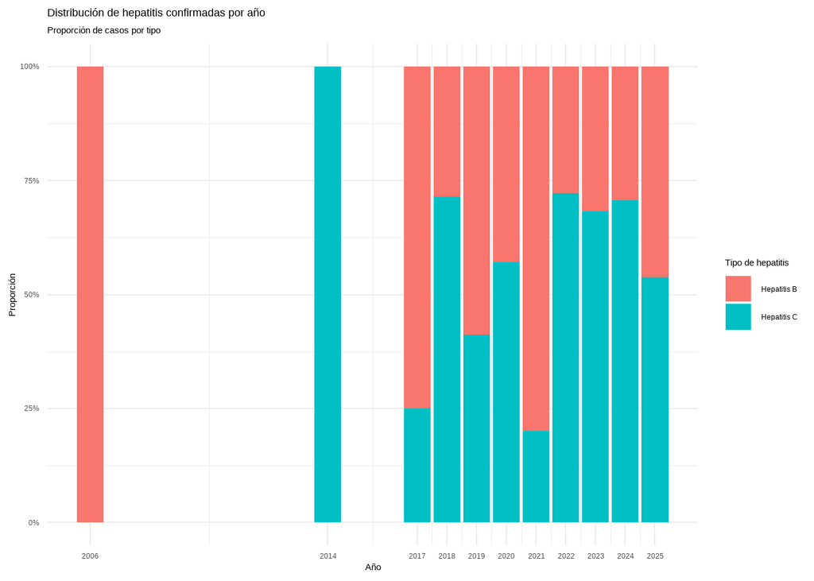

### **Hepatitis B**

Los casos de Hepatitis B notificados corresponden a un total de 71 casos.

Clasificación de casos de HVB

Período 2018–2025

| Clasificación de HBV | Número de casos | Porcentaje sobre el total de HVB |
| --- | --- | --- |
| Crónica | 39 | 54.9 |
| Sin datos | 15 | 21.1 |
| Resuelta | 6 | 8.5 |
| Aguda | 4 | 5.6 |
| Aguda y resuelta | 4 | 5.6 |
| Descartado | 3 | 4.2 |
| Total | 71 | 99.9 |

Los casos de Hepatitis B confirmados corresponden a un total de 53 casos.

Frecuencia absoluta y relativa de co-infección VIH.

Co-infección en HVB

Período 2018–2025

| Co-infección | Número de casos | Porcentaje |
| --- | --- | --- |
| NO | 33 | 62.3 |
| Sin datos | 14 | 26.4 |
| HIV | 4 | 7.5 |
| HIV/HCV | 1 | 1.9 |
| NA | 1 | 1.9 |
| Total | 53 | 100.0 |

### **Hepatitis B Aguda**

Distribución de grupo etario de hepatitis aguda y agudas resueltas: analizar el impacto de la vacunación.

Grupos etarios HVB aguda

Período 2018–2025

| Grupo etario | Casos | Porcentaje |
| --- | --- | --- |
| De 25 a 34 años | 2 | 25.0 |
| De 35 a 44 años | 3 | 37.5 |
| De 45 a 65 años | 2 | 25.0 |
| Mayores de 65 años | 1 | 12.5 |
| Total | 8 | 100.0 |

### **Hepatitis B Crónica**

Distribución de grupo etario de HBV crónica

Grupos etarios HVB crónica

Período 2018–2025

| Grupo etario | Casos | Porcentaje |
| --- | --- | --- |
| De 20 a 24 años | 1 | 2.6 |
| De 25 a 34 años | 3 | 7.7 |
| De 35 a 44 años | 11 | 28.2 |
| De 45 a 65 años | 18 | 46.2 |
| Mayores de 65 años | 6 | 15.4 |
| Total | 39 | 100.1 |

Porcentaje de pacientes crónicos en estadio de cirrosis

Cirrosis en HVB

| Cirrosis | Casos | Porcentaje |
| --- | --- | --- |
| NO | 23 | 59.0 |
| Sin datos | 14 | 35.9 |
| SI | 2 | 5.1 |
| Total | 39 | 100.0 |

Porcentaje de pacientes crónicos que evolucionan a HCC

Hepatocarcinoma en HVB

| HCC | Casos | Porcentaje |
| --- | --- | --- |
| NO | 27 | 69.2 |
| Sin datos | 12 | 30.8 |
| Total | 39 | 100.0 |

Porcentaje de pacientes crónicos que evolucionan a transplante

Transplante en HVB

| Transplante | Casos | Porcentaje |
| --- | --- | --- |
| NO | 27 | 69.2 |
| Sin datos | 12 | 30.8 |
| Total | 39 | 100.0 |

Porcentaje de pacientes crónicos que evolucionan a muerte

Fallecidos en HVB

| Fallecido | Casos | Porcentaje |
| --- | --- | --- |
| NO | 38 | 97.4 |
| SI | 1 | 2.6 |
| Total | 39 | 100.0 |

Porcentaje de pacientes crónicos que pierden el seguimiento

Pérdida de seguimiento HVB

| Seguimiento | Casos | Porcentaje |
| --- | --- | --- |
| SI | 25 | 64.1 |
| NO | 14 | 35.9 |
| Total | 39 | 100.0 |

Porcentaje de pacientes tratados en cronicos

Tratamiento en HVB

| Tratamiento | Casos | Porcentaje |
| --- | --- | --- |
| NO | 16 | 41.0 |
| Sin datos | 12 | 30.8 |
| SI | 11 | 28.2 |
| Total | 39 | 100.0 |

```
 Grupo de evento Casos Porcentaje
           Total     0          0
```

Casos perdidos del sistema de salud (sin datos , agudas, perdida de seguimiento)

```
 Pérdida de seguimiento Casos Porcentaje
                     SI    30       56.6
                     NO    19       35.8
         No corresponde     4        7.5
                  Total    53       99.9
```

### **Hepatitis C**

Casos diagnosticados con CV+ (confirmados)

Clasificación de casos de HVC

Período 2018–2025

| Clasificación de HVC | Número de casos | Porcentaje sobre el total de notificados de HVC |
| --- | --- | --- |
| SI | 62 | 62.0 |
| DESCARTADO | 21 | 21.0 |
| SIN DATOS | 17 | 17.0 |
| Total | 100 | 100.0 |

Coinfeccion HIV/HBV (menos descartados)

Co-infección en casos confirmados de HVC

Período 2018–2025

| Co-infección | Número de casos | Porcentaje sobre el total de confirmados de HVC |
| --- | --- | --- |
| NO | 52 | 83.9 |
| HIV | 8 | 12.9 |
| VHB | 1 | 1.6 |
| NA | 1 | 1.6 |
| Total | 62 | 100.0 |

Pacientes en estadio de cirrosis

Pacientes con cirrosis en HVC

Período 2018–2025

| Cirrosis | Número de casos | Porcentaje sobre el total de crónicos con HVC |
| --- | --- | --- |
| NO | 37 | 59.7 |
| SI | 17 | 27.4 |
| SIN DATOS | 8 | 12.9 |
| Total | 62 | 100.0 |

Porcentaje de pacientes con evolución a HCC

Pacientes con hepatocarcinoma en HVC

Período 2018–2025

| Hepatocarcinoma | Número de casos | Porcentaje sobre el total de confirmados HVC |
| --- | --- | --- |
| NO | 52 | 83.9 |
| SIN DATOS | 7 | 11.3 |
| SI | 3 | 4.8 |
| Total | 62 | 100.0 |

Porcentaje de pacientes con evolución a transplante

Pacientes transplantados en HVC

Período 2018–2025

| Transplante | Número de casos | Porcentaje sobre el total de crónicos con HVC |
| --- | --- | --- |
| NO | 56 | 90.3 |
| SIN DATOS | 6 | 9.7 |
| Total | 62 | 100.0 |

Porcentaje de pacientes con evolución a muerte

Pacientes fallecidos con HVC

Período 2018–2025

| Fallecido | Número de casos | Porcentaje |
| --- | --- | --- |
| NO | 50 | 80.6 |
| SI | 12 | 19.4 |
| Total | 62 | 100.0 |

Porcentaje de Pacientes tratados (confirmados)

Pacientes que recibieron tratamiento con HVC

Período 2018–2025

| Tratamiento | Número de casos | Porcentaje |
| --- | --- | --- |
| SI | 42 | 67.7 |
| NO | 13 | 21.0 |
| SIN DATOS | 6 | 9.7 |
| Tto en curso | 1 | 1.6 |
| Total | 62 | 100.0 |

De los pacientes tratados porcentaje con RVS

Pacientes con RVS en HVC

Período 2018–2025

| Respuesta viral sostenida | Número de casos | Porcentaje |
| --- | --- | --- |
| SI | 35 | 83.3 |
| SIN DATOS | 4 | 9.5 |
| Tto en curso | 3 | 7.1 |
| Total | 42 | 99.9 |

Casos perdidos del sistema de salud (sin datos , cronicos perdida de seguimiento)

[output not shown]

```
 Perdida de seguimiento Casos Porcentaje
                     NO    35       56.5
                     SI    24       38.7
              SIN DATOS     2        3.2
                   <NA>     1        1.6
                  Total    62      100.0
```

Identificar fuente de notificación en pacientes sin datos para categorización

## **5.Distribución geográfica**

Casos de Hepatitis B notificados según localidad de residencia

```
    Localidad Residencia Casos Porcentaje
                 USHUAIA    42       59.2
              RIO GRANDE    13       18.3
                 TOLHUIN     7        9.9
 *SIN DATO* (*SIN DATO*)     2        2.8
              *sin dato*     2        2.8
  CIUDAD DE BUENOS AIRES     1        1.4
            RIO GALLEGOS     1        1.4
                   SALTA     1        1.4
             SAN IGNACIO     1        1.4
                   TIGRE     1        1.4
                   Total    71      100.0
```

Casos de Hepatitis C notificados según localidad de residencia

```
    Localidad Residencia Casos Porcentaje
              RIO GRANDE    53         53
                 USHUAIA    34         34
                 TOLHUIN     5          5
 *SIN DATO* (*SIN DATO*)     4          4
              *sin dato*     2          2
              LAGO PUELO     1          1
             RIO TERCERO     1          1
                   Total   100        100
```

Dsitribución por grupo etario de todos los casos HV notificados en SNVS entre 2018 y 2025

```
 Grupo etario diagnóstico Casos Porcentaje
            De 2 a 4 años     1        0.5
          De 20 a 24 años     6        2.9
          De 25 a 34 años    24       11.6
          De 35 a 44 años    57       27.5
          De 45 a 65 años    99       47.8
       Mayores de 65 años    20        9.7
                    Total   207      100.0
```

Dsitribución por sexo de todos los casos HV notificados en SNVS entre 2018 y 2025

```
 Sexo Legal Casos Porcentaje
          M   115       55.6
          F    92       44.4
      Total   207      100.0
```

## **6.Factores de Riesgo Identificados: NO SE EVALUARA EN ESTA INSTANCIA**

Uso de drogas EV

Transfusiones previas a 1994

Personas privadas de libertad

Coinfección VIH

Pacientes en hemodiálisis

Personal de salud

## **7.Análisis y problemas detectados**

La provincia presenta una carga de enfermedad compatible con su perfil demográfico, aunque se evidencia probable subdiagnóstico, particularmente en hepatitis C.

El bajo volumen poblacional constituye una oportunidad estratégica para implementar programas de microeliminación, dado que la identificación activa y tratamiento sistemático permitirían alcanzar metas de eliminación en un plazo factible.

La organización estructurada de la atención hepatológica, combinando evaluación presencial, seguimiento remoto y articulación interdisciplinaria, se presenta como modelo eficiente en contexto insular.

La detección temprana reduce significativamente:

Internaciones.

Derivaciones fuera de la provincia.

Costos asociados a enfermedad avanzada.

Mortalidad prematura. Problemas detectados

Baja pesquisa

perdida de seguimiento, Falta de circuito protocolizado entre ciudades: perdida de pacientes derivados de infectologia y de banco de sangre y la clinica sn jorge

Pérdida de pacientes de banco de sangre por falta de notificación, incluso los descartados por laboratorio

## **8.Recomendaciones**

Implementar estrategia provincial de pesquisa sistematizada

Generar circuito de derivación en banco de sangre

Capacitación APS para fomentar pesquisa. Optimizar registro epidemiológico provincial.

Involucrar personal del sistema Privado para la notificación y derivación

Registro provincial unificado Público - Privado con sistema ágil de derivación de pacientes detectados

Generar sistema permanente de Revinculación

Reasegurar vacunación

## **9.Conclusiones**

La Provincia de Tierra del Fuego posee condiciones demográficas que permiten proyectar la eliminación de las hepatitis virales como problema de salud pública mediante una estrategia organizada, sostenida y basada en diagnóstico oportuno y tratamiento integral.

La planificación estructurada de la atención hepatológica constituye una herramienta sanitaria estratégica que impacta favorablemente en morbimortalidad, calidad de vida y sostenibilidad del sistema de salud provincial.